# hw2

Maxim Holmatov

04.04.2017

# Требуемые пакеты

```r
library(DESeq2)
library(ggplot2)
library(pheatmap)
library(amap)
library(dbscan)
options(width=120)
```

# Загрузка данных

```r
counts <- read.csv("GSE89225_Illumina_counts.csv", row.names=1)

conditions <- read.csv("conditions.csv", row.names=1)
```

# Подготовка данных

- Возьмем весь датасет с аутлаером
- Создадим DeseqDataSet объект (дизайн не важен)
- Оставим только 8000 экспрессированных генов
- Используем rlog(dds) для получения логарифмированных значений экспрессии

```r
dds <- DESeqDataSetFromMatrix(countData = counts,
                              colData = conditions,
                              design = ~ tissue + cells)


dds <- dds[head(order(rowSums(counts(dds)), decreasing = T), n=8000), ]
dds <- DESeq(dds)
rlog_dds <- rlog(counts(dds))
rownames(rlog_dds) <- rownames(dds)
```

# Задание 1: иерархическая кластеризация

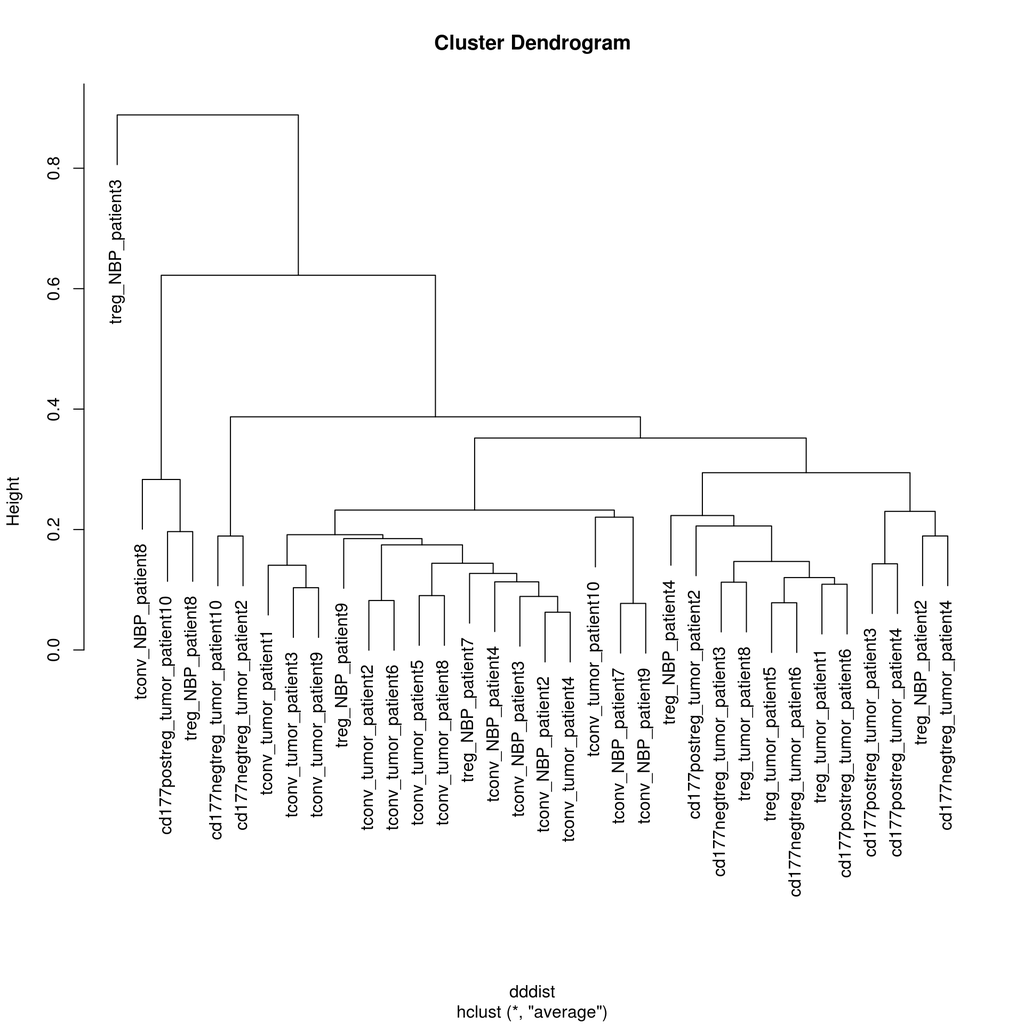

```r
corelations <- cor(rlog_dds)

nonLikelihood <- 1 - corelations
dddist <- dist(corelations)

av_clust <- hclust(dddist, method = "average")
plot(av_clust)
```

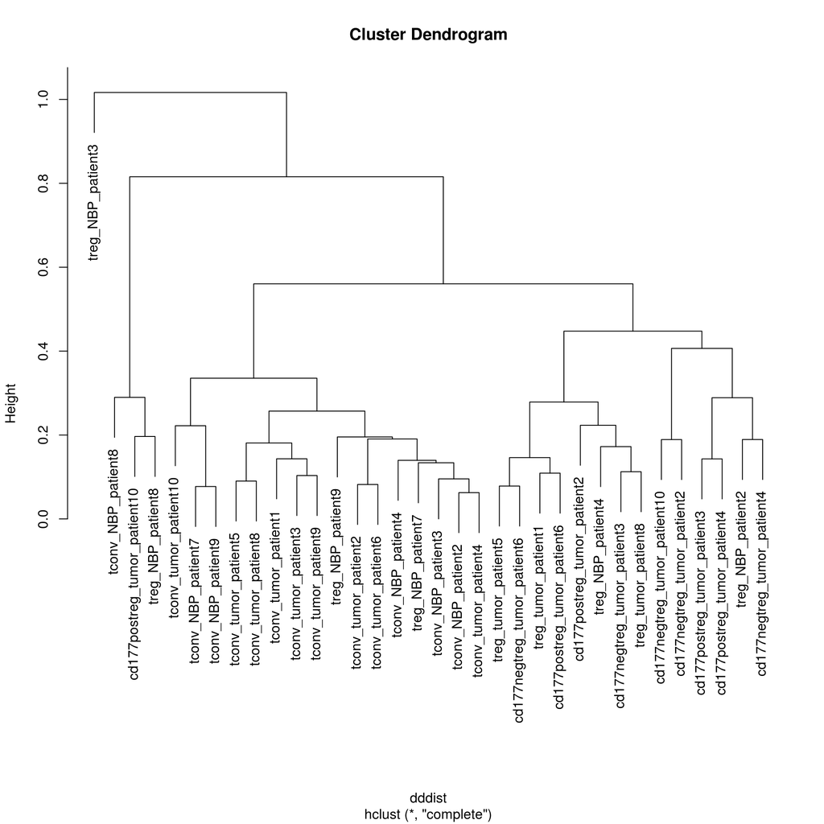

```r
cp_clust <- hclust(dddist, method = "complete")
plot(cp_clust)
```

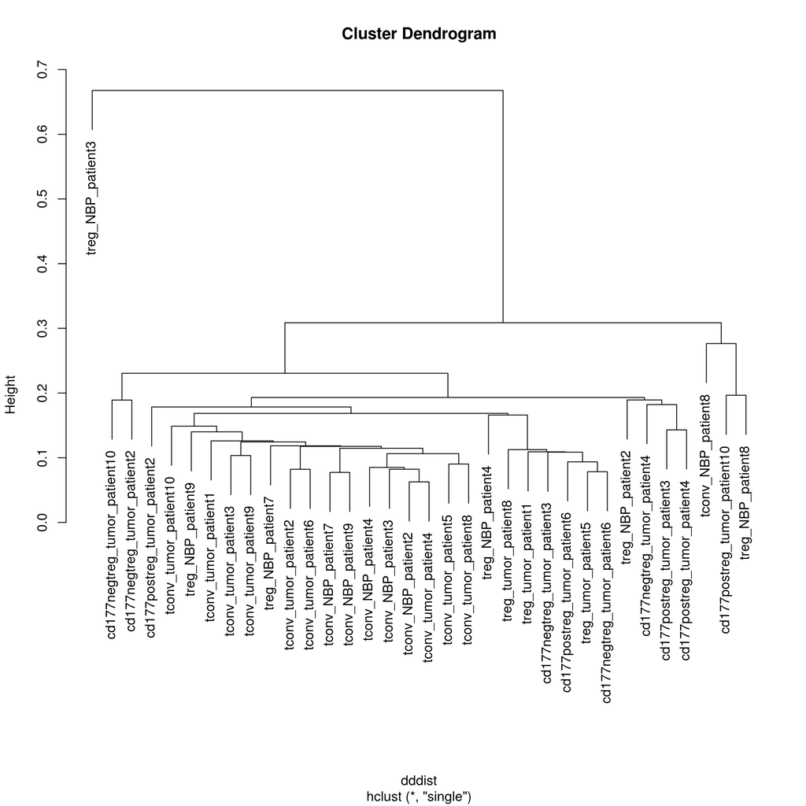

```r
si_clust <- hclust(dddist, method = "single")
plot(si_clust)
```

# Задание 2: K-means

- Удалим аутлаера

```r
counts$treg_NBP_patient3 <- NULL
conditions <- conditions[rownames(conditions) != 'treg_NBP_patient3',]
dds <- DESeqDataSetFromMatrix(countData = counts,
                              colData = conditions,
                              design = ~ tissue + cells)
dds <- dds[head(order(rowSums(counts(dds)), decreasing = T), n=8000), ]
dds <- DESeq(dds)
rlog_dds <- rlog(counts(dds))
rownames(rlog_dds) <- rownames(dds)
```

- Используем функцию Kmeans из пакета amap с методом “correlation”, c количеством кластеров равным 6. (Вы можете выбрать своё количество кластеров), и максимальным количеством итераций равным 20000
- После этого вы можете достать соотвествие каждого гена кластеру с помощью элемента листа с названием “cluster”
- После этого от вас потребуется эту кластеризацию изобразить на хитмапе: гены должны быть отсортированы по кластерам, а столбцы сначала по клеткам, а затем по тканям.

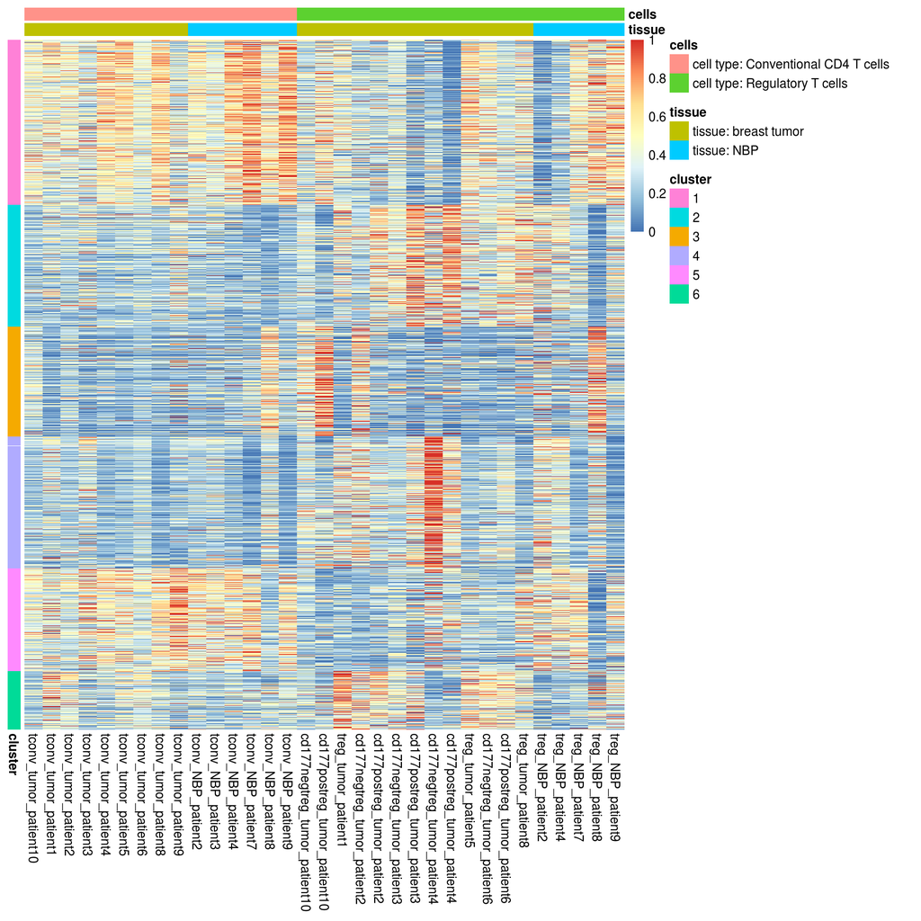

```r
clustering  <- Kmeans(rlog_dds, method =  "correlation", centers = 6, iter.max = 20000)
clusters <- as.data.frame(clustering$cluster)
colnames(clusters) <- c('cluster')
clusters$cluster <- as.factor(clusters$cluster)
rownames(clusters) <- rownames(rlog_dds)

counts.norm <- counts(dds, normalized=TRUE)


to_visualise <- counts.norm[order(clusters$cluster), order(conditions[, 2],conditions[, 1])]

to_visualise <- t(apply(to_visualise, 1, function(r) {
  (r - min(r)) / (max(r) - min(r))
}))

pheatmap(to_visualise,
         show_rownames = F, cluster_rows = F,
         cluster_cols=F,
         annotation_col = conditions,
         annotation_row = clusters)
```

# Density based algortihms

```r
proj <- read.csv("projection.csv", row.names=1)
pm <- as.matrix(proj)
```

### Некластеризованные данные

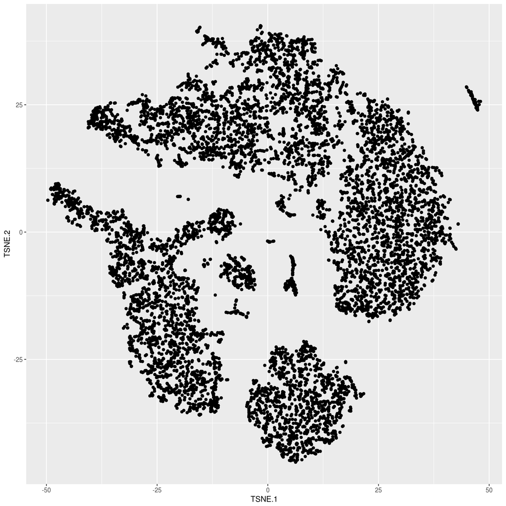

```r
ggplot(data = proj, aes(x = TSNE.1, y = TSNE.2))+
  geom_point()
```

### Подбор параметров кластеризации

В пакете рекомендовано выбирать minPts равным или большим чем размерность данных + 1. eps рекомендовано подбирать по графику kNNdistplot.

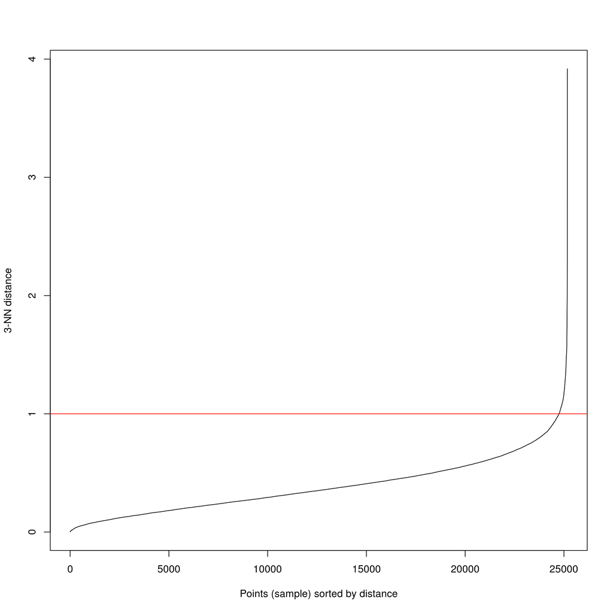

```r
kNNdistplot(pm, k = 3)
abline(h=1, col='red')
```

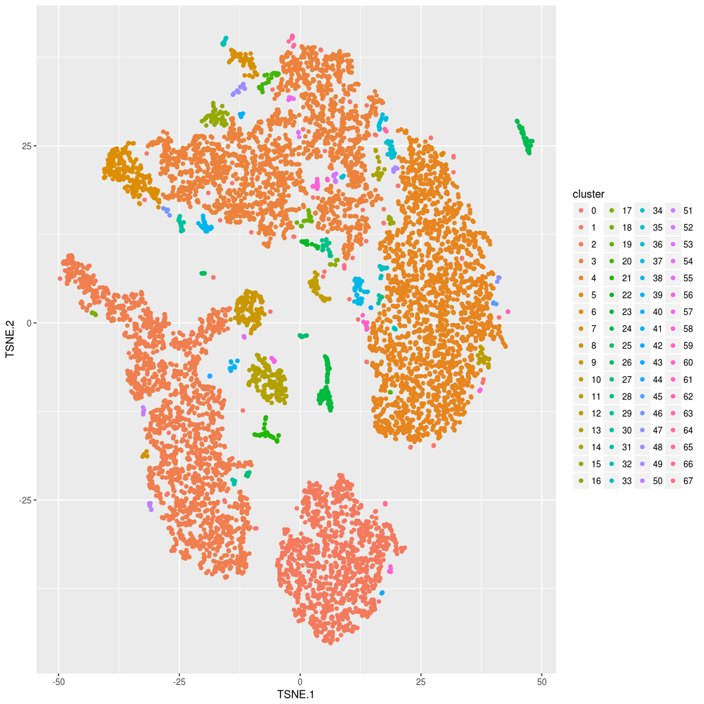

```r
res <- dbscan(pm, eps = 1, minPts = 3)
proj$cluster <- as.factor(res$cluster)
ggplot(data = proj, aes(x = TSNE.1, y = TSNE.2, col = cluster))+
  geom_point()
```

Выглядит ужасно, поэтому все подберем на глаз)

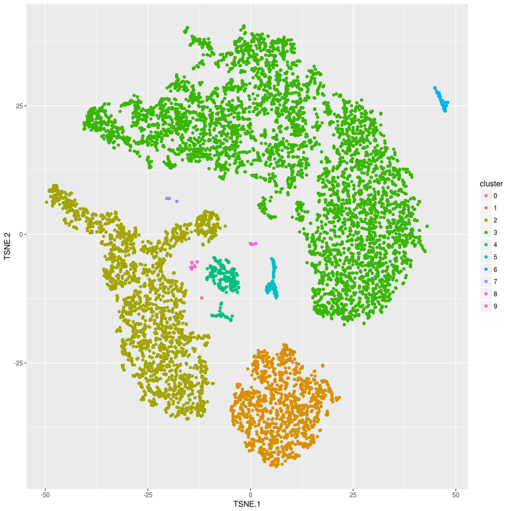

```r
res <- dbscan(pm, eps = 2.5, minPts = 3)
proj$cluster <- as.factor(res$cluster)
ggplot(data = proj, aes(x = TSNE.1, y = TSNE.2, col = cluster))+
  geom_point()
```

Потрясающе.